# R Bootcamp: Day 3 AM

# More fun with base R

## Lines: `type = "l"`

```r
plot(sort(counties$income), type = "l")
```

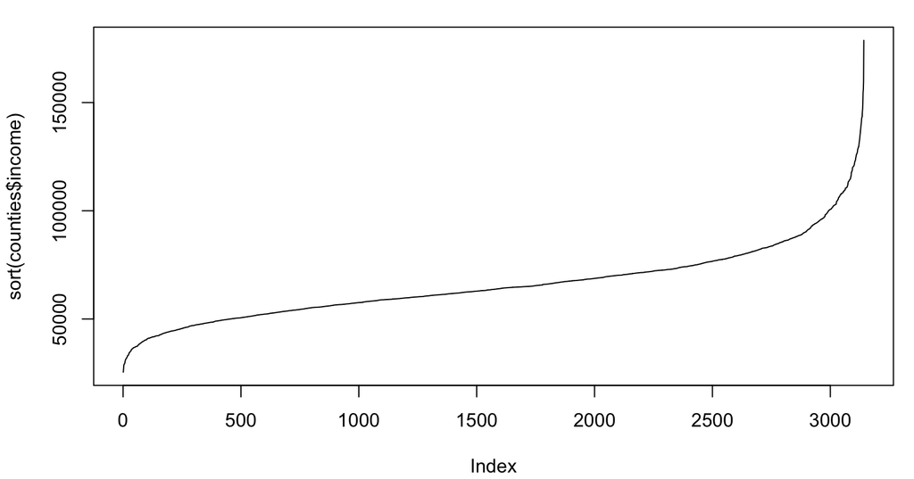

*What does the rightmost tail tell you?*

## Histograms

A better way to visualize the distribution of one variable (binned):

```r
hist(counties$income, breaks = 50) ## number of bins
```

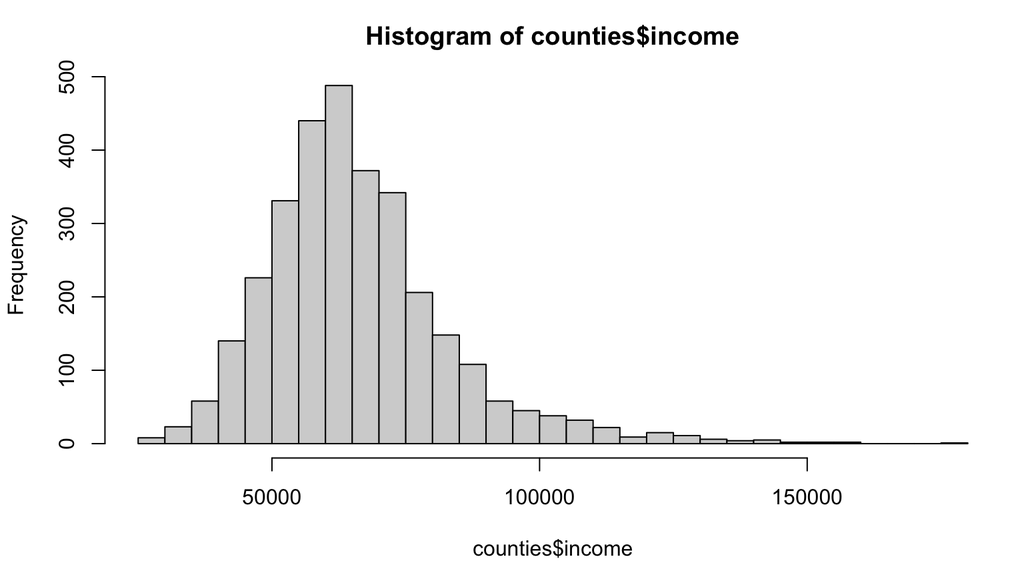

## Bar plots: counting categories

Use `barplot()` for categorical variables:

```r
table(counties$region) |> barplot()
```

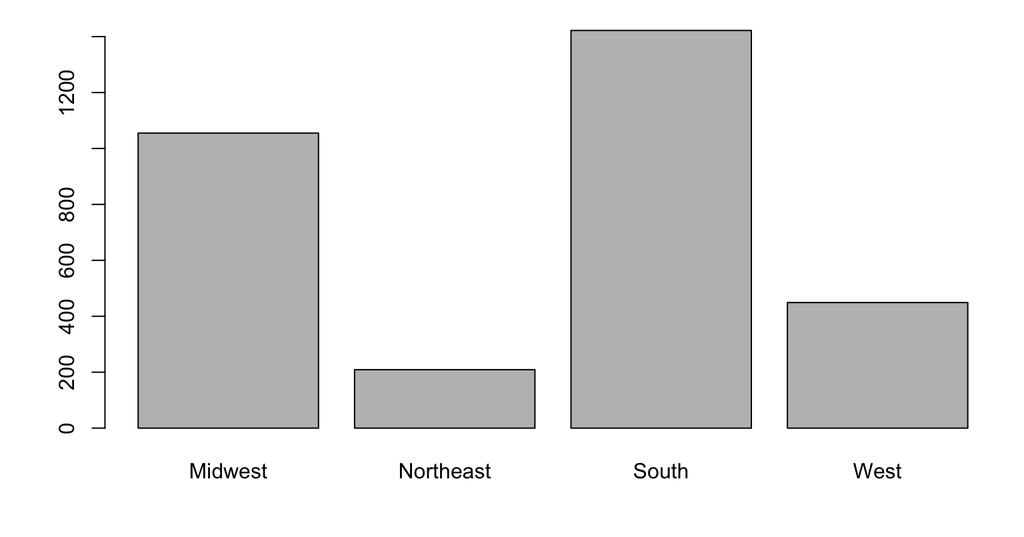

(Categories appear alphabetically by default.)

## Densities: a smooth histogram

`density()` estimates the distribution; `plot()` draws the estimate:

```r
density(counties$income, na.rm = TRUE) |> plot()
```

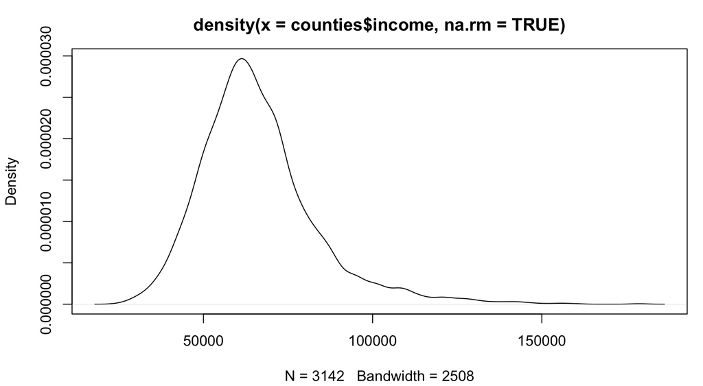

## Densities can smooth *past* data: misleading

```r
d <- density(counties$income, na.rm = TRUE)

range(counties$income, na.rm = TRUE)
range(d$x)
```

```
[1]  25425 178707
[1]  17899.87 186232.13
```

The curve starts ~$7,000 below the poorest county. Density estimates commonly leak below zero.

The `cut` argument controls this:

```r
d0 <- density(counties$income, na.rm = TRUE, cut = 0)
range(d0$x)
```

```
[1]  25425 178707
```

## Base R plotting is a canvas

`plot()` (or `hist()`, `barplot()`, …) starts a **fresh canvas**

Then each of these adds ink **on top** of whatever is there:

- `points()` — more points
- `lines()` — more lines
- `abline()` — straight reference lines
- `legend()` — add a legend

The canvas is *cumulative*. To change something underneath, start over.

## Layer by layer

Start the canvas — every county in gray:

```r
nj <- counties[counties$state == "New Jersey", ]

plot(counties$income, counties$rent, pch = 19, cex = 0.4, col = "gray")
```

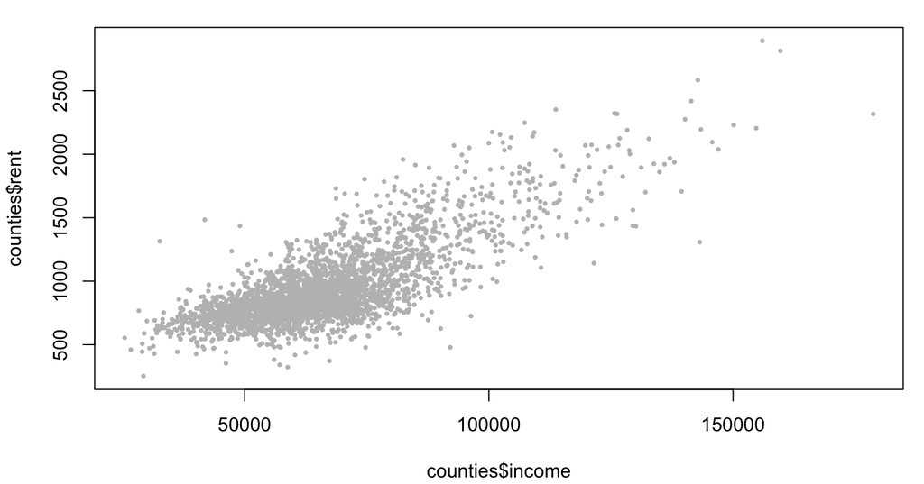

## Layer by layer

The canvas is live. Add `points()` on top:

```r
points(nj$income, nj$rent, pch = 19, col = "orange")
```

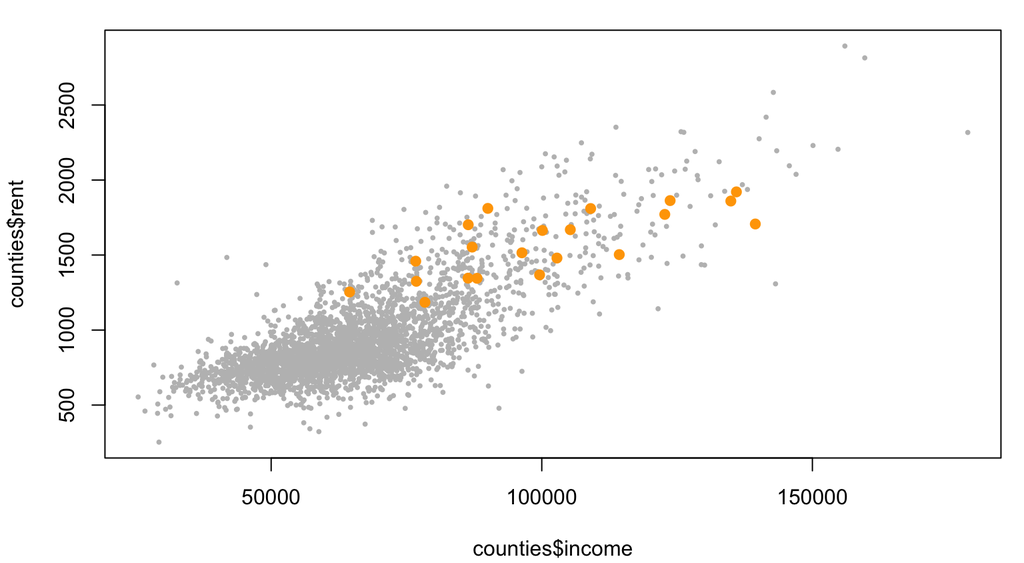

## Layer by layer

…and `abline()` draw a reference line:

```r
abline(h = median(counties$rent, na.rm = TRUE), lwd = 2, col = "steelblue")
```

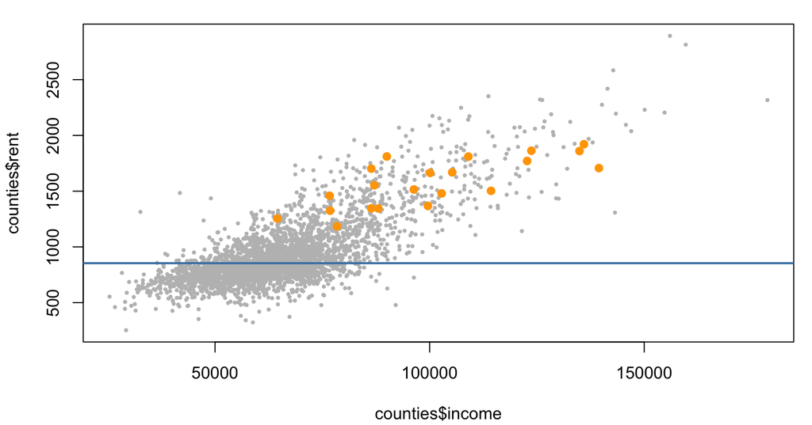

*Every* New Jersey county sits above the national median rent

## Always label your layers

The same trick compares distributions — start with the Northeast:

```r
plot(density(counties$income[counties$region == "Northeast"], na.rm = TRUE),
    col = "steelblue", lwd = 2, main = "Income by region"
)
```

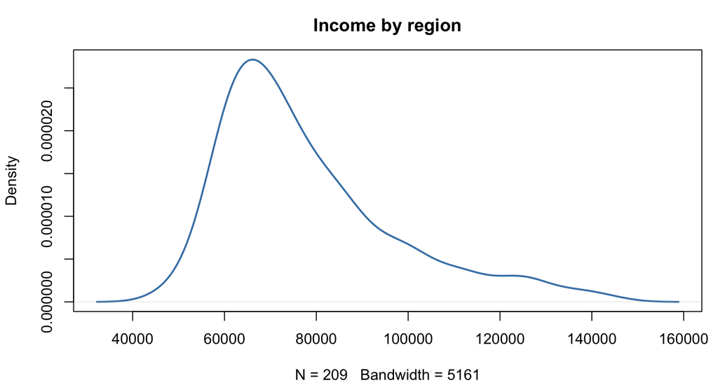

## Always label your layers

`lines()` overlays the South:

```r
lines(density(counties$income[counties$region == "South"], na.rm = TRUE),
    col = "firebrick", lwd = 2
)
```

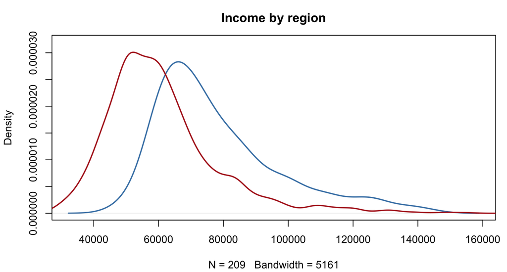

## Always label your layers

`legend()` for a legend:

```r
legend("topright",
    legend = c("Northeast", "South"),
    col = c("steelblue", "firebrick"), lwd = 2
)
```

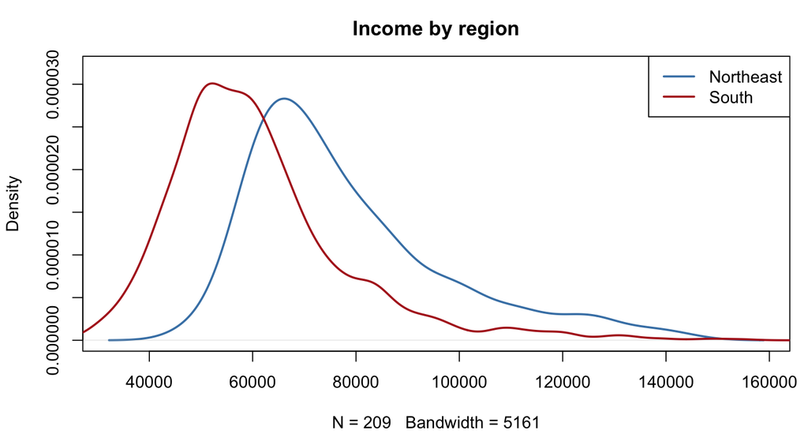

## Many plots at once: `par()`

`par()` sets graphics options for the whole device — `mfrow` makes a grid that fills plot by plot:

```r
par(mfrow = c(1, 2))
hist(counties$income, main = "Income")
hist(counties$rent, main = "Rent")
```

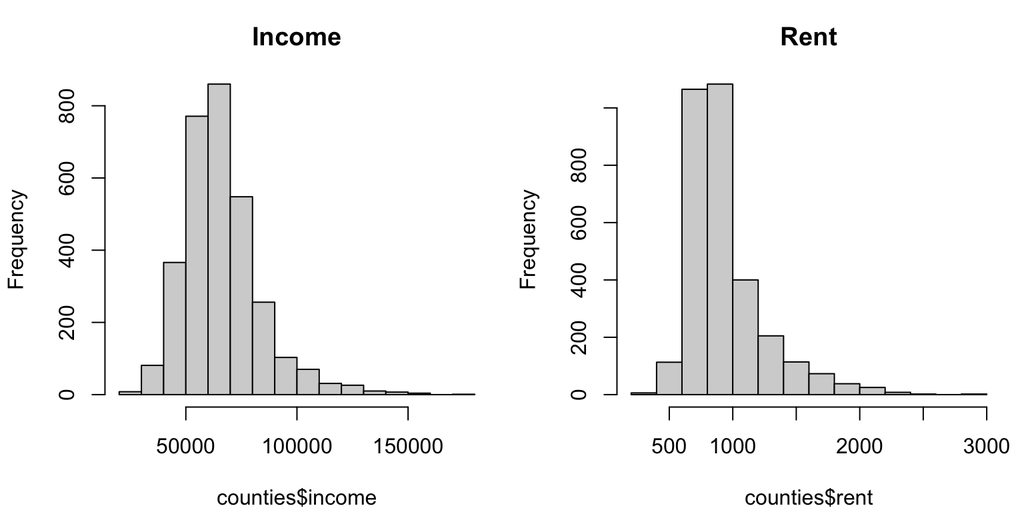

## `par()` is global

Every plot from now on lands in that grid until you put it back:

```r
par(mfrow = c(1, 1))
```

`par()` controls dozens more settings: margins (`mar` and `oma`), text size (`cex`), etc.

Base R plots are *side effects* that depend on the state of the graphics device. The functions return `NULL`.

## Maps are just plots

`plot()` knows what to do with a geometry column:

```r
st_geometry(shapes) |> plot()
```

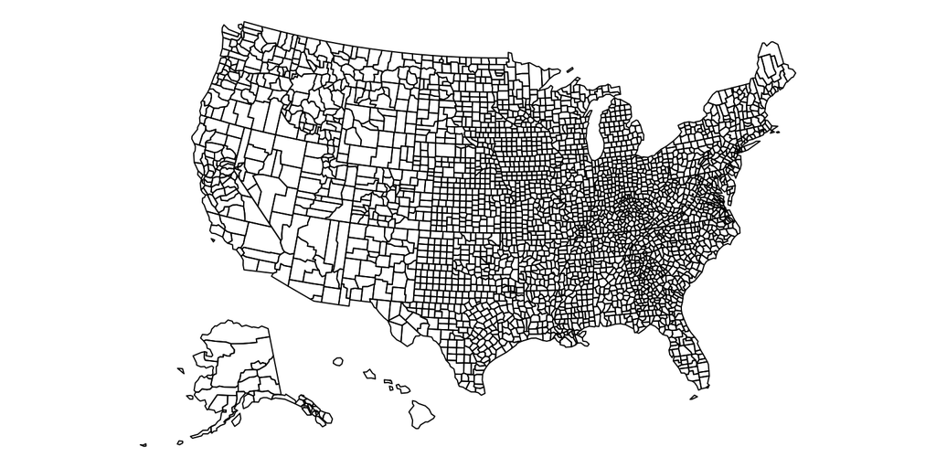

What happens if you just call `plot(shapes)`?

## State colors

```r
plot(shapes["state"], main = NULL)
```

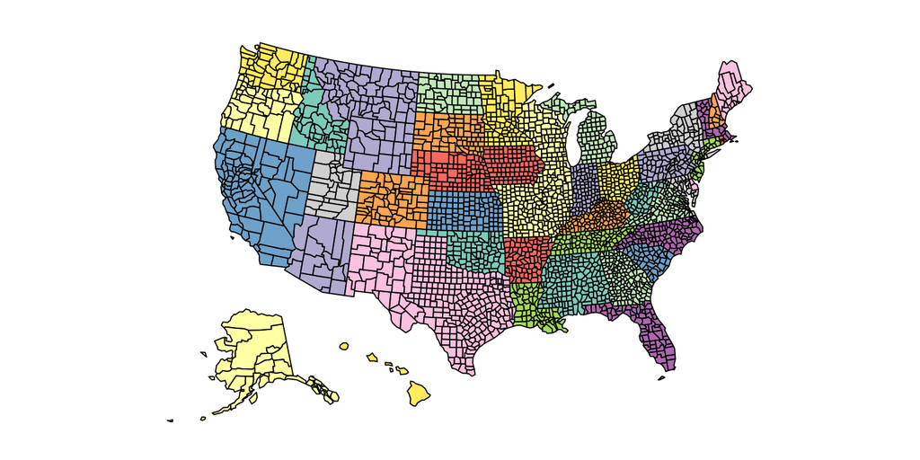

## Counties to states

```r
shapes |>
    group_by(state) |>
    summarise(geometry = st_union(geometry)) |>
    plot(main = NULL)
```

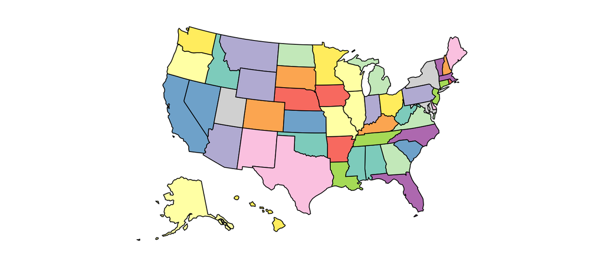